```python
import numpy as np
import pandas as pd
import matplotlib.pyplot as plt
import seaborn as sns
%matplotlib inline
from scipy.stats import zscore
from sklearn import metrics
from sklearn.metrics import accuracy_score, confusion_matrix, recall_score, precision_score, f1_score, auc, roc_curve
from sklearn.metrics import classification_report
from sklearn.model_selection import train_test_split
from sklearn.linear_model import LogisticRegression
from sklearn.naive_bayes import GaussianNB
from sklearn.neighbors import KNeighborsClassifier
from sklearn.model_selection import cross_val_score
from sklearn.model_selection import GridSearchCV
```

```python
bnk_ln_df = pd.read_csv('Bank_Personal_Loan_Modelling-1.csv')
```

```python
bnk_ln_df.head(50)
```

|  | ID | Age | Experience | Income | ZIP Code | Family | CCAvg | Education | Mortgage | Personal Loan | Securities Account | CD Account | Online | CreditCard |
| --- | --- | --- | --- | --- | --- | --- | --- | --- | --- | --- | --- | --- | --- | --- |
| 0 | 1 | 25 | 1 | 49 | 91107 | 4 | 1.6 | 1 | 0 | 0 | 1 | 0 | 0 | 0 |
| 1 | 2 | 45 | 19 | 34 | 90089 | 3 | 1.5 | 1 | 0 | 0 | 1 | 0 | 0 | 0 |
| 2 | 3 | 39 | 15 | 11 | 94720 | 1 | 1.0 | 1 | 0 | 0 | 0 | 0 | 0 | 0 |
| 3 | 4 | 35 | 9 | 100 | 94112 | 1 | 2.7 | 2 | 0 | 0 | 0 | 0 | 0 | 0 |
| 4 | 5 | 35 | 8 | 45 | 91330 | 4 | 1.0 | 2 | 0 | 0 | 0 | 0 | 0 | 1 |
| 5 | 6 | 37 | 13 | 29 | 92121 | 4 | 0.4 | 2 | 155 | 0 | 0 | 0 | 1 | 0 |
| 6 | 7 | 53 | 27 | 72 | 91711 | 2 | 1.5 | 2 | 0 | 0 | 0 | 0 | 1 | 0 |
| 7 | 8 | 50 | 24 | 22 | 93943 | 1 | 0.3 | 3 | 0 | 0 | 0 | 0 | 0 | 1 |
| 8 | 9 | 35 | 10 | 81 | 90089 | 3 | 0.6 | 2 | 104 | 0 | 0 | 0 | 1 | 0 |
| 9 | 10 | 34 | 9 | 180 | 93023 | 1 | 8.9 | 3 | 0 | 1 | 0 | 0 | 0 | 0 |
| 10 | 11 | 65 | 39 | 105 | 94710 | 4 | 2.4 | 3 | 0 | 0 | 0 | 0 | 0 | 0 |
| 11 | 12 | 29 | 5 | 45 | 90277 | 3 | 0.1 | 2 | 0 | 0 | 0 | 0 | 1 | 0 |
| 12 | 13 | 48 | 23 | 114 | 93106 | 2 | 3.8 | 3 | 0 | 0 | 1 | 0 | 0 | 0 |
| 13 | 14 | 59 | 32 | 40 | 94920 | 4 | 2.5 | 2 | 0 | 0 | 0 | 0 | 1 | 0 |
| 14 | 15 | 67 | 41 | 112 | 91741 | 1 | 2.0 | 1 | 0 | 0 | 1 | 0 | 0 | 0 |
| 15 | 16 | 60 | 30 | 22 | 95054 | 1 | 1.5 | 3 | 0 | 0 | 0 | 0 | 1 | 1 |
| 16 | 17 | 38 | 14 | 130 | 95010 | 4 | 4.7 | 3 | 134 | 1 | 0 | 0 | 0 | 0 |
| 17 | 18 | 42 | 18 | 81 | 94305 | 4 | 2.4 | 1 | 0 | 0 | 0 | 0 | 0 | 0 |
| 18 | 19 | 46 | 21 | 193 | 91604 | 2 | 8.1 | 3 | 0 | 1 | 0 | 0 | 0 | 0 |
| 19 | 20 | 55 | 28 | 21 | 94720 | 1 | 0.5 | 2 | 0 | 0 | 1 | 0 | 0 | 1 |
| 20 | 21 | 56 | 31 | 25 | 94015 | 4 | 0.9 | 2 | 111 | 0 | 0 | 0 | 1 | 0 |
| 21 | 22 | 57 | 27 | 63 | 90095 | 3 | 2.0 | 3 | 0 | 0 | 0 | 0 | 1 | 0 |
| 22 | 23 | 29 | 5 | 62 | 90277 | 1 | 1.2 | 1 | 260 | 0 | 0 | 0 | 1 | 0 |
| 23 | 24 | 44 | 18 | 43 | 91320 | 2 | 0.7 | 1 | 163 | 0 | 1 | 0 | 0 | 0 |
| 24 | 25 | 36 | 11 | 152 | 95521 | 2 | 3.9 | 1 | 159 | 0 | 0 | 0 | 0 | 1 |
| 25 | 26 | 43 | 19 | 29 | 94305 | 3 | 0.5 | 1 | 97 | 0 | 0 | 0 | 1 | 0 |
| 26 | 27 | 40 | 16 | 83 | 95064 | 4 | 0.2 | 3 | 0 | 0 | 0 | 0 | 0 | 0 |
| 27 | 28 | 46 | 20 | 158 | 90064 | 1 | 2.4 | 1 | 0 | 0 | 0 | 0 | 1 | 1 |
| 28 | 29 | 56 | 30 | 48 | 94539 | 1 | 2.2 | 3 | 0 | 0 | 0 | 0 | 1 | 1 |
| 29 | 30 | 38 | 13 | 119 | 94104 | 1 | 3.3 | 2 | 0 | 1 | 0 | 1 | 1 | 1 |
| 30 | 31 | 59 | 35 | 35 | 93106 | 1 | 1.2 | 3 | 122 | 0 | 0 | 0 | 1 | 0 |
| 31 | 32 | 40 | 16 | 29 | 94117 | 1 | 2.0 | 2 | 0 | 0 | 0 | 0 | 1 | 0 |
| 32 | 33 | 53 | 28 | 41 | 94801 | 2 | 0.6 | 3 | 193 | 0 | 0 | 0 | 0 | 0 |
| 33 | 34 | 30 | 6 | 18 | 91330 | 3 | 0.9 | 3 | 0 | 0 | 0 | 0 | 0 | 0 |
| 34 | 35 | 31 | 5 | 50 | 94035 | 4 | 1.8 | 3 | 0 | 0 | 0 | 0 | 1 | 0 |
| 35 | 36 | 48 | 24 | 81 | 92647 | 3 | 0.7 | 1 | 0 | 0 | 0 | 0 | 0 | 0 |
| 36 | 37 | 59 | 35 | 121 | 94720 | 1 | 2.9 | 1 | 0 | 0 | 0 | 0 | 0 | 1 |
| 37 | 38 | 51 | 25 | 71 | 95814 | 1 | 1.4 | 3 | 198 | 0 | 0 | 0 | 0 | 0 |
| 38 | 39 | 42 | 18 | 141 | 94114 | 3 | 5.0 | 3 | 0 | 1 | 1 | 1 | 1 | 0 |
| 39 | 40 | 38 | 13 | 80 | 94115 | 4 | 0.7 | 3 | 285 | 0 | 0 | 0 | 1 | 0 |
| 40 | 41 | 57 | 32 | 84 | 92672 | 3 | 1.6 | 3 | 0 | 0 | 1 | 0 | 0 | 0 |
| 41 | 42 | 34 | 9 | 60 | 94122 | 3 | 2.3 | 1 | 0 | 0 | 0 | 0 | 0 | 0 |
| 42 | 43 | 32 | 7 | 132 | 90019 | 4 | 1.1 | 2 | 412 | 1 | 0 | 0 | 1 | 0 |
| 43 | 44 | 39 | 15 | 45 | 95616 | 1 | 0.7 | 1 | 0 | 0 | 0 | 0 | 1 | 0 |
| 44 | 45 | 46 | 20 | 104 | 94065 | 1 | 5.7 | 1 | 0 | 0 | 0 | 0 | 1 | 1 |
| 45 | 46 | 57 | 31 | 52 | 94720 | 4 | 2.5 | 1 | 0 | 0 | 0 | 0 | 0 | 1 |
| 46 | 47 | 39 | 14 | 43 | 95014 | 3 | 0.7 | 2 | 153 | 0 | 0 | 0 | 1 | 0 |
| 47 | 48 | 37 | 12 | 194 | 91380 | 4 | 0.2 | 3 | 211 | 1 | 1 | 1 | 1 | 1 |
| 48 | 49 | 56 | 26 | 81 | 95747 | 2 | 4.5 | 3 | 0 | 0 | 0 | 0 | 0 | 1 |
| 49 | 50 | 40 | 16 | 49 | 92373 | 1 | 1.8 | 1 | 0 | 0 | 0 | 0 | 0 | 1 |

Dropping ID column since it does not affect whether the customer will take a loan or not. Verified that the ID is continous so there isn't any gap in the dataset

```python
bnk_ln = bnk_ln_df.drop('ID', axis=1)
```

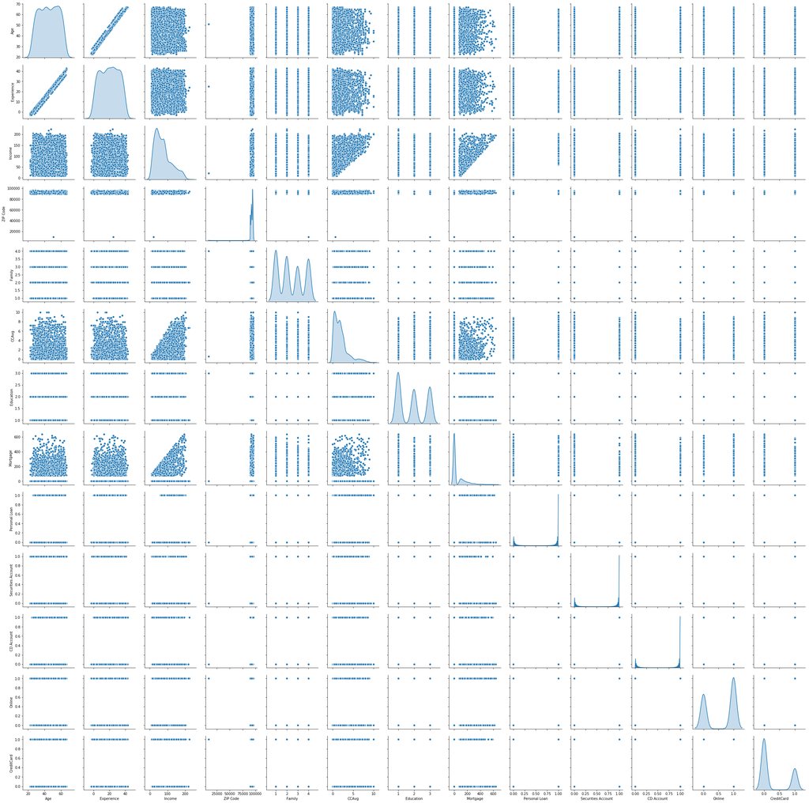

```python
sns.pairplot(bnk_ln, diag_kind='kde')
```

```python
bnk_ln.corr()
```

|  | Age | Experience | Income | ZIP Code | Family | CCAvg | Education | Mortgage | Personal Loan | Securities Account | CD Account | Online | CreditCard |
| --- | --- | --- | --- | --- | --- | --- | --- | --- | --- | --- | --- | --- | --- |
| Age | 1.000000 | 0.994215 | -0.055269 | -0.029216 | -0.046418 | -0.052012 | 0.041334 | -0.012539 | -0.007726 | -0.000436 | 0.008043 | 0.013702 | 0.007681 |
| Experience | 0.994215 | 1.000000 | -0.046574 | -0.028626 | -0.052563 | -0.050077 | 0.013152 | -0.010582 | -0.007413 | -0.001232 | 0.010353 | 0.013898 | 0.008967 |
| Income | -0.055269 | -0.046574 | 1.000000 | -0.016410 | -0.157501 | 0.645984 | -0.187524 | 0.206806 | 0.502462 | -0.002616 | 0.169738 | 0.014206 | -0.002385 |
| ZIP Code | -0.029216 | -0.028626 | -0.016410 | 1.000000 | 0.011778 | -0.004061 | -0.017377 | 0.007383 | 0.000107 | 0.004704 | 0.019972 | 0.016990 | 0.007691 |
| Family | -0.046418 | -0.052563 | -0.157501 | 0.011778 | 1.000000 | -0.109275 | 0.064929 | -0.020445 | 0.061367 | 0.019994 | 0.014110 | 0.010354 | 0.011588 |
| CCAvg | -0.052012 | -0.050077 | 0.645984 | -0.004061 | -0.109275 | 1.000000 | -0.136124 | 0.109905 | 0.366889 | 0.015086 | 0.136534 | -0.003611 | -0.006689 |
| Education | 0.041334 | 0.013152 | -0.187524 | -0.017377 | 0.064929 | -0.136124 | 1.000000 | -0.033327 | 0.136722 | -0.010812 | 0.013934 | -0.015004 | -0.011014 |
| Mortgage | -0.012539 | -0.010582 | 0.206806 | 0.007383 | -0.020445 | 0.109905 | -0.033327 | 1.000000 | 0.142095 | -0.005411 | 0.089311 | -0.005995 | -0.007231 |
| Personal Loan | -0.007726 | -0.007413 | 0.502462 | 0.000107 | 0.061367 | 0.366889 | 0.136722 | 0.142095 | 1.000000 | 0.021954 | 0.316355 | 0.006278 | 0.002802 |
| Securities Account | -0.000436 | -0.001232 | -0.002616 | 0.004704 | 0.019994 | 0.015086 | -0.010812 | -0.005411 | 0.021954 | 1.000000 | 0.317034 | 0.012627 | -0.015028 |
| CD Account | 0.008043 | 0.010353 | 0.169738 | 0.019972 | 0.014110 | 0.136534 | 0.013934 | 0.089311 | 0.316355 | 0.317034 | 1.000000 | 0.175880 | 0.278644 |
| Online | 0.013702 | 0.013898 | 0.014206 | 0.016990 | 0.010354 | -0.003611 | -0.015004 | -0.005995 | 0.006278 | 0.012627 | 0.175880 | 1.000000 | 0.004210 |
| CreditCard | 0.007681 | 0.008967 | -0.002385 | 0.007691 | 0.011588 | -0.006689 | -0.011014 | -0.007231 | 0.002802 | -0.015028 | 0.278644 | 0.004210 | 1.000000 |

2 major class are family size(4 classes) and education level(3 classes) There is no particular relationship between credit card expenditure and size of the family.

There is a slight increase in the expenditure of graduates compared to UG(Not significant)

There are UG who seem to earn more than graduates and Professionals. There appears to be no correlation between age and income and the data appears to be a cloud.

The relation between income and family appears to be small. Slight increase for size 2 and then decreases as size increases.

For zip code and income there are areas where the income is quite high and areas where it is significantly low. Credit card average expenditure and mortgage follows a similar trend. Family size is evenly spread. Correlation between zip code and personal loan is nearly zero. So dropping zip code until we get more evidence that people in certain areas purchase personal loan.

The relation between age and experience is nearly linear. So we can drop either one. Age has a slightly better negative correlation with personal loan No significant relation between personal loan and these two but extremely young or less experienced people don't purchase loan.

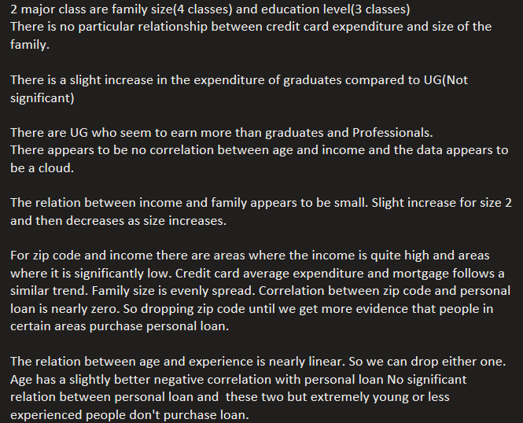

```python
bnk_ln_fin = bnk_ln.drop('ZIP Code', axis=1)
```

```python
bnk_ln_fin.info()
```

```
<class 'pandas.core.frame.DataFrame'>
RangeIndex: 5000 entries, 0 to 4999
Data columns (total 12 columns):
Age                   5000 non-null int64
Experience            5000 non-null int64
Income                5000 non-null int64
Family                5000 non-null int64
CCAvg                 5000 non-null float64
Education             5000 non-null int64
Mortgage              5000 non-null int64
Personal Loan         5000 non-null int64
Securities Account    5000 non-null int64
CD Account            5000 non-null int64
Online                5000 non-null int64
CreditCard            5000 non-null int64
dtypes: float64(1), int64(11)
memory usage: 468.8 KB
```

```python
bnk_ln_fin.describe()
```

|  | Age | Experience | Income | Family | CCAvg | Education | Mortgage | Personal Loan | Securities Account | CD Account | Online | CreditCard |
| --- | --- | --- | --- | --- | --- | --- | --- | --- | --- | --- | --- | --- |
| count | 5000.000000 | 5000.000000 | 5000.000000 | 5000.000000 | 5000.000000 | 5000.000000 | 5000.000000 | 5000.000000 | 5000.000000 | 5000.00000 | 5000.000000 | 5000.000000 |
| mean | 45.338400 | 20.104600 | 73.774200 | 2.396400 | 1.937938 | 1.881000 | 56.498800 | 0.096000 | 0.104400 | 0.06040 | 0.596800 | 0.294000 |
| std | 11.463166 | 11.467954 | 46.033729 | 1.147663 | 1.747659 | 0.839869 | 101.713802 | 0.294621 | 0.305809 | 0.23825 | 0.490589 | 0.455637 |
| min | 23.000000 | -3.000000 | 8.000000 | 1.000000 | 0.000000 | 1.000000 | 0.000000 | 0.000000 | 0.000000 | 0.00000 | 0.000000 | 0.000000 |
| 25% | 35.000000 | 10.000000 | 39.000000 | 1.000000 | 0.700000 | 1.000000 | 0.000000 | 0.000000 | 0.000000 | 0.00000 | 0.000000 | 0.000000 |
| 50% | 45.000000 | 20.000000 | 64.000000 | 2.000000 | 1.500000 | 2.000000 | 0.000000 | 0.000000 | 0.000000 | 0.00000 | 1.000000 | 0.000000 |
| 75% | 55.000000 | 30.000000 | 98.000000 | 3.000000 | 2.500000 | 3.000000 | 101.000000 | 0.000000 | 0.000000 | 0.00000 | 1.000000 | 1.000000 |
| max | 67.000000 | 43.000000 | 224.000000 | 4.000000 | 10.000000 | 3.000000 | 635.000000 | 1.000000 | 1.000000 | 1.00000 | 1.000000 | 1.000000 |

There seems to be significant outliers in Income, CCAvg and Mortgage

There are a few rows in experience is a negative number. Since experience cannot be negative, we'll have to change this

```python
bnk_ln_fin.loc[bnk_ln_fin['Experience'] < 0].count()
```

```
Age                   52
Experience            52
Income                52
Family                52
CCAvg                 52
Education             52
Mortgage              52
Personal Loan         52
Securities Account    52
CD Account            52
Online                52
CreditCard            52
dtype: int64
```

Taking the absolute value for Experience

```python
bnk_ln_fin['Experience'] = bnk_ln_fin['Experience'].abs()
```

The target variable is personal loan

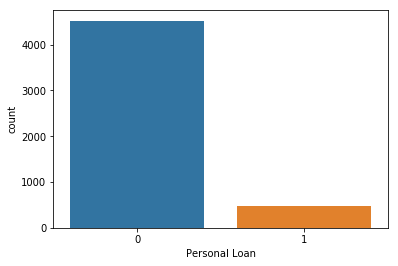

```python
sns.countplot(bnk_ln_fin['Personal Loan'])
```

There is an extremely high number of people who rejected the personal loan than people who bought it, as a result our model may not accurately predict whether a person will buy a personal loan but it will predict when a person won't buy. Better apprach would be get more data so as to increase the number of people who bought personal loan.

```python
X = bnk_ln_fin.drop('Personal Loan', axis=1)
y = bnk_ln_fin['Personal Loan']
```

Normalizing data using Z score since the scales are too large

```python
X = X.apply(zscore)
```

Splitting data into test and train (70:30)

```python
random_state=5
test_size=0.3

X_train, X_test, y_train, y_test = train_test_split(X,y, test_size=test_size, random_state=random_state)
```

### Logistic Regression

```python
model = LogisticRegression()
```

```python
model.fit(X_train, y_train)
```

```
LogisticRegression(C=1.0, class_weight=None, dual=False, fit_intercept=True,
          intercept_scaling=1, max_iter=100, multi_class='warn',
          n_jobs=None, penalty='l2', random_state=None, solver='warn',
          tol=0.0001, verbose=0, warm_start=False)
```

```python
model.score(X_test, y_test)
```

```
0.9526666666666667
```

```python
y_predictProb = model.predict_proba(X_train)
fpr, tpr, thresholds = roc_curve(y_train, y_predictProb[::,1])
```

```python
roc_auc = auc(fpr, tpr)
roc_auc
```

```
0.9600329475784579
```

```python
optimalF1 = 0
optimalTh = 0
thresholds[0:10]
for th in thresholds:
    preds = np.where(model.predict_proba(X_train)[:,1] > th, 1, 0)
    f1Score = f1_score(y_train, preds)
    if(optimalF1 < f1Score):
        optimalF1 = f1Score
        optimalTh = th

print(optimalF1)
print(optimalTh)
```

```
0.7275590551181103
0.36231666442194915
```

```python
THRESHOLD = optimalTh
y_pred = np.where(model.predict_proba(X_test)[:,1] > THRESHOLD, 1, 0)
```

```python
accuracy_score(y_test,y_pred)
```

```
0.9466666666666667
```

```python
print(confusion_matrix(y_test,y_pred))
print(classification_report(y_test, y_pred))
```

```
[[1315   36]
 [  44  105]]
              precision    recall  f1-score   support

           0       0.97      0.97      0.97      1351
           1       0.74      0.70      0.72       149

   micro avg       0.95      0.95      0.95      1500
   macro avg       0.86      0.84      0.85      1500
weighted avg       0.95      0.95      0.95      1500
```

**Insights for Logistic Regression Model:**

- Out of 1351 people who didn't get a loan, the model was able to predict 1315 times.
- Out of 149 people getting a personal loan, the model was able to predict 105 times.
- The model has incorrectly predicted 44 people who will be getting a personal loan as people who won't be getting it.
- The model has incorrectly predicted 36 people who won't get it as people who will get it.
- Of the times the model predicts that a person will get a loan, it is correct for about 74% of the time
- Of the times the person does get a loan, the model is able to predict 70% of the time

### KNN model

```python
NNH = KNeighborsClassifier()
```

```python
param_grid = {'n_neighbors':np.arange(1,73,2)}
NNH_gscv = GridSearchCV(NNH,param_grid, cv=10, scoring='accuracy')
```

```python
NNH_gscv.fit(X,y)
```

```
GridSearchCV(cv=10, error_score='raise-deprecating',
       estimator=KNeighborsClassifier(algorithm='auto', leaf_size=30, metric='minkowski',
           metric_params=None, n_jobs=None, n_neighbors=5, p=2,
           weights='uniform'),
       fit_params=None, iid='warn', n_jobs=None,
       param_grid={'n_neighbors': array([ 1,  3,  5,  7,  9, 11, 13, 15, 17, 19, 21, 23, 25, 27, 29, 31, 33,
       35, 37, 39, 41, 43, 45, 47, 49, 51, 53, 55, 57, 59, 61, 63, 65, 67,
       69, 71])},
       pre_dispatch='2*n_jobs', refit=True, return_train_score='warn',
       scoring='accuracy', verbose=0)
```

```python
NNH_gscv.best_params_
```

```
{'n_neighbors': 3}
```

```python
NNH2 = KNeighborsClassifier(3)
NNH2.fit(X_train,y_train)
```

```
KNeighborsClassifier(algorithm='auto', leaf_size=30, metric='minkowski',
           metric_params=None, n_jobs=None, n_neighbors=3, p=2,
           weights='uniform')
```

```python
y_pred = NNH2.predict(X_test)
```

```python
NNH2.score(X_test,y_test)
```

```
0.958
```

```python
print(confusion_matrix(y_test,y_pred))
print(classification_report(y_test, y_pred))
```

```
[[1343    8]
 [  55   94]]
              precision    recall  f1-score   support

           0       0.96      0.99      0.98      1351
           1       0.92      0.63      0.75       149

   micro avg       0.96      0.96      0.96      1500
   macro avg       0.94      0.81      0.86      1500
weighted avg       0.96      0.96      0.95      1500
```

**Insights for KNN model:**

- Of the 1351 people who didn't get the loan, the model has identified 1343.
- Of the 149 people who get the personal loan, the model has identified 94.
- The model has incorrectly identified 55 people who will be getting personal loan as people who won't get it.
- The model has incorrectly identified 8 people who won't get personal loan as people who will get it.
- When the model has predicted a person will get a loan, it is correct 92% of the time
- When a person does get a loan, the model is able to predict 63% of the time
- The model is able to identify people who won't be getting personal loans better than people who get personal loans.
- This is expected since there are more data points for people who won't get personal loan.

### Naïve Bayes

```python
model = GaussianNB()
model.fit(X_train, y_train)
```

```
GaussianNB(priors=None, var_smoothing=1e-09)
```

```python
model.score(X_test, y_test)
```

```
0.874
```

```python
y_predictProb = model.predict_proba(X_test)
```

```python
fpr, tpr, thresholds = roc_curve(y_test, y_predictProb[::,1])
```

```python
roc_auc = auc(fpr, tpr)
roc_auc
```

```
0.9215246970923849
```

```python
optimalF1 = 0
optimalTh = 0
for th in thresholds:
    y_pred = np.where(model.predict_proba(X_test)[:,1] > th, 1, 0)
    f1Score = f1_score(y_test, y_pred)
    if(optimalF1 < f1Score):
        optimalF1 = f1Score
        optimalTh = th

print(optimalF1)
print(optimalTh)
```

```
0.5515789473684211
0.03789828648553127
```

```python
THRESHOLD = optimalTh
y_pred = np.where(model.predict_proba(X_test)[:,1] > THRESHOLD, 1, 0)
```

```python
accuracy_score(y_test,y_pred)
```

```
0.858
```

```python
print(confusion_matrix(y_test,y_pred))
print(classification_report(y_test, y_pred))
```

```
[[1156  195]
 [  18  131]]
              precision    recall  f1-score   support

           0       0.98      0.86      0.92      1351
           1       0.40      0.88      0.55       149

   micro avg       0.86      0.86      0.86      1500
   macro avg       0.69      0.87      0.73      1500
weighted avg       0.93      0.86      0.88      1500
```

**Insights for Naïve Bayes model:**

- Of the 1351 people who won't get the loan, the model is able to identify 1156 people
- Of the 149 people who will get the loan, the model is able to identify 131 people
- The model has incorrectly identified 195 who won't be getting the loan as people who will get the loan.
- The model has incorrectly identified 18 people who will be getting the loan as people who won't get it.
- Of the times the model predicts a person will get the loan, only 40% is correct.
- Of the times the person does get a loan, the model is able to predict 88% of the time

### Final Insights

- KNN model has the highest accuracy at 95% and when it predicts a person will get a loan, it is correct 92% of the time and for all the people who get a loan, the model is able to predict them correctly 63% of the time.
- Logistic regression has the second highest accuracy at 94% and when it predicts a person will get a loan, it is correct 74% of the time and for all the people who get a loan, the model is able to predict them correctly 70% of the time.
- Naïve Bayes has the lowest accuracy at 85% and when it predicts a person will get a loan, it is correct 40% of the time and for all the people who get a loan, the model is able to predict them correctly 88% of the time.
- Based on the above conclusion and since the required model has to predict people who will actually get a loan better, the **KNN model** with the precision of 92% is the best model.